# IS 6487: Modeling with Classification Trees

Meag Tessmann

# Load and Transform Data

### Data dictionary

- ANSWERED: Indicator for whether the call was answered.
- INCOME: Annual income of customer
- FEMALE: Indicator for whether the customer is female
- AGE: Age of customer
- JOB: Indicator for job type.
- NUM_DEPENDENTS: Number of dependents.
- RENT: Indicator for whether customer rents
- OWN_RES: Indicator for whether customer owns residence
- NEW_CAR: Indicator of whether the customer owns a new car
- CHK_ACCT: Number of checking accounts
- SAV_ACCT: Number of savings accounts
- NUM_ACCTS: Total number of other accounts
- MOBILE: Indicator for whether the call back number is mobile
- PRODUCT: Type of product purchased. (0 represents no purchase)

```r
#import data, remove product which is not known until after, and modify variables which should be factors
d <- read_csv("adviseinvest_clean.csv")  %>%
  select(-product) %>%
  mutate(answered = factor(ifelse(answered==0, "no","yes")),
         female = factor(female),
         job = factor(job),
         rent = factor(rent),
         own_res = factor(own_res),
         new_car = factor(new_car),
         mobile = factor(mobile))
```

# Questions

## Q1.

The target variable for this modeling exercise is ANSWERED. In this dataset, what proportion of calls were answered?

```r
# answered true over total answered
sum(d$answered== 'yes')/sum(d$answered=='no' | d$answered=='yes')
```

```
## [1] 0.543
```

## Q2.

Fit a tree model to the outcome using just one variable, income. We’ll call this the “income model.” What is the accuracy of the income model?

```r
# fit tree
(income_model <- rpart(answered ~ income, data = d))
```

```
## n= 5000
##
## node), split, n, loss, yval, (yprob)
##       * denotes terminal node
##
##  1) root 5000 2285 yes (0.4570000 0.5430000)
##    2) income>=39135 1385  495 no (0.6425993 0.3574007) *
##    3) income< 39135 3615 1395 yes (0.3858921 0.6141079)
##      6) income< 36355 3490 1390 yes (0.3982808 0.6017192)
##       12) income>=4295 3450 1390 yes (0.4028986 0.5971014)
##         24) income< 9595 480  223 no (0.5354167 0.4645833)
##           48) income>=7890 183   39 no (0.7868852 0.2131148) *
##           49) income< 7890 297  113 yes (0.3804714 0.6195286)
##             98) income< 4455 25    0 no (1.0000000 0.0000000) *
##             99) income>=4455 272   88 yes (0.3235294 0.6764706) *
##         25) income>=9595 2970 1133 yes (0.3814815 0.6185185) *
##       13) income< 4295 40    0 yes (0.0000000 1.0000000) *
##      7) income>=36355 125    5 yes (0.0400000 0.9600000) *
```

```r
# accuracy of model
sum(predict(income_model, type="class") == d$answered)/nrow(d)
```

```
## [1] 0.648
```

## Q3.

What is the entropy in the income model’s first terminal (leaf) node ?

The node is defined as: 2) income>=39135. (If you are not seeing this output then make sure you have turned the outcome variable into a factor.)

### First terminal node

Split: income>=39135

Total n for leaf: 1385

Incorrect observations: 495

Majority: no

Proportion no: 0.6425993

Proportion yes: 0.3574007

```r
# Calculate entropy - -p1*log(p1)-p2*log(p2)

-0.6425993*log(0.6425993) - 0.3574007*log(0.3574007)
```

```
## [1] 0.651908
```

### Q4.

Fit a tree model of the outcome using all the predictors (again, not including product, and having changed the indicators and the outcome into factors). We’ll call this the “tree model.” Create and upload a visualization of the tree model. (This will be somewhat illegible due to the complexity of the tree.)

```r
(tree_model <- rpart(answered ~ ., data=d))
```

```
## n= 5000
##
## node), split, n, loss, yval, (yprob)
##       * denotes terminal node
##
##    1) root 5000 2285 yes (0.45700000 0.54300000)
##      2) chk_acct< 2.5 3234 1322 no (0.59121831 0.40878169)
##        4) sav_acct< 1.5 2590  925 no (0.64285714 0.35714286)
##          8) income>=79840 243   22 no (0.90946502 0.09053498) *
##          9) income< 79840 2347  903 no (0.61525352 0.38474648)
##           18) mobile=0 2203  790 no (0.64139809 0.35860191)
##             36) age< 25.5 542  117 no (0.78413284 0.21586716)
##               72) chk_acct< 1.5 514   89 no (0.82684825 0.17315175) *
##               73) chk_acct>=1.5 28    0 yes (0.00000000 1.00000000) *
##             37) age>=25.5 1661  673 no (0.59482240 0.40517760)
##               74) female=1 170   33 no (0.80588235 0.19411765) *
##               75) female=0 1491  640 no (0.57075788 0.42924212)
##                150) income< 10310 220   50 no (0.77272727 0.22727273) *
##                151) income>=10310 1271  590 no (0.53579858 0.46420142)
##                  302) income>=11000 1232  551 no (0.55275974 0.44724026)
##                    604) income>=26300 607  223 no (0.63261944 0.36738056)
##                     1208) job=2 387   77 no (0.80103359 0.19896641) *
##                     1209) job=0,1,3 220   74 yes (0.33636364 0.66363636) *
##                    605) income< 26300 625  297 yes (0.47520000 0.52480000)
##                     1210) age>=31.5 421  174 no (0.58669834 0.41330166)
##                       2420) income< 22380 320   95 no (0.70312500 0.29687500) *
##                       2421) income>=22380 101   22 yes (0.21782178 0.78217822) *
##                     1211) age< 31.5 204   50 yes (0.24509804 0.75490196) *
##                  303) income< 11000 39    0 yes (0.00000000 1.00000000) *
##           19) mobile=1 144   31 yes (0.21527778 0.78472222) *
##        5) sav_acct>=1.5 644  247 yes (0.38354037 0.61645963)
##         10) age< 34 361  179 no (0.50415512 0.49584488)
##           20) num_accts>=1.5 237   87 no (0.63291139 0.36708861) *
##           21) num_accts< 1.5 124   32 yes (0.25806452 0.74193548) *
##         11) age>=34 283   65 yes (0.22968198 0.77031802) *
##      3) chk_acct>=2.5 1766  373 yes (0.21121178 0.78878822)
##        6) income>=38910 387  190 yes (0.49095607 0.50904393)
##         12) job=3 110   11 no (0.90000000 0.10000000) *
##         13) job=1,2 277   91 yes (0.32851986 0.67148014)
##           26) num_accts< 1.5 33    0 no (1.00000000 0.00000000) *
##           27) num_accts>=1.5 244   58 yes (0.23770492 0.76229508)
##             54) new_car=1 49    9 no (0.81632653 0.18367347) *
##             55) new_car=0 195   18 yes (0.09230769 0.90769231) *
##        7) income< 38910 1379  183 yes (0.13270486 0.86729514) *
```

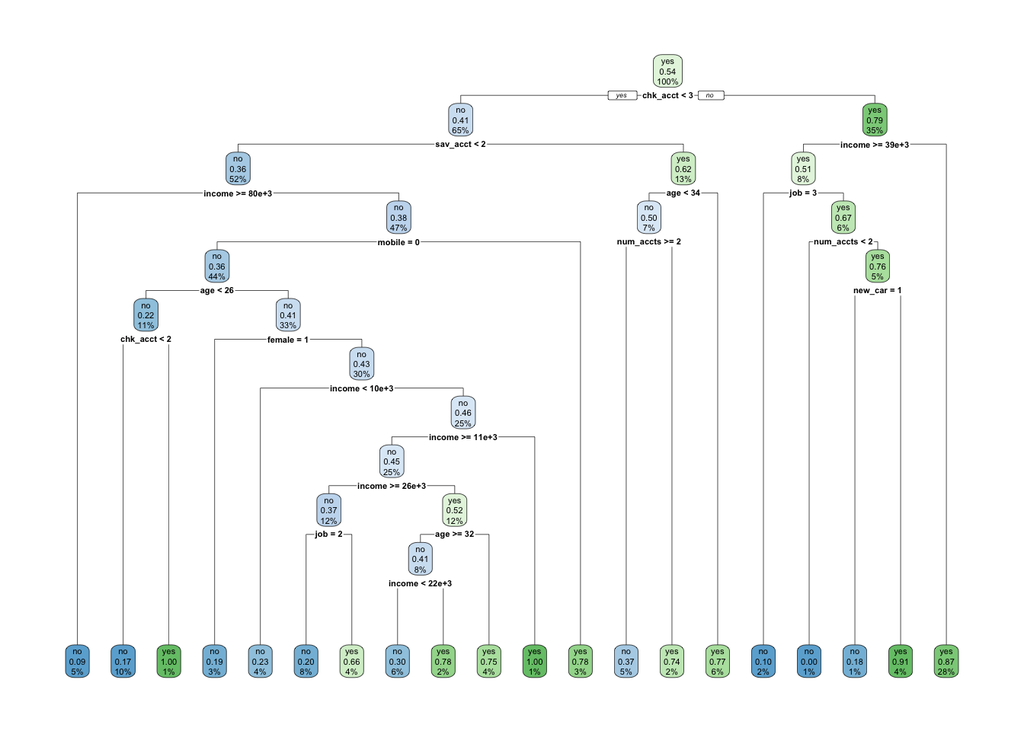

```r
rpart.plot(tree_model)
```

### Q5.

What is the accuracy of the tree model?

```r
# accuracy of model
sum(predict(tree_model, type="class") == d$answered)/nrow(d)
```

```
## [1] 0.8104
```

### Q6.

What is the top variable in terms of variable importance?

```r
tree_model$variable.importance
```

```
##   chk_acct     income        age        job  num_accts   sav_acct
## 388.777315 236.099864 128.479038 126.860658 101.297615  75.077203
##     mobile    new_car     female       rent    own_res
##  51.366503  45.185264  19.575343   8.527121   6.128717
```